# Theoratical Generation of Data

- Strain Life (Morrow equation): $$ \frac{\Delta \epsilon}{2} = \frac{\sigma'_f}{E}(2N_f)^b + \epsilon'_f(2N_f)^c $$
- Reversal Stress Ratio: $$ \frac{\Delta \sigma}{2} = \sigma_{max} = \sigma_f'(2N_f)^b $$
- SWT(Smith,Watson and Topper fatigue damage parameter): $$ SWT = \sigma_{max}\frac{\Delta\epsilon}{2} = \frac{(\sigma_f'^2)(2N_f)^{2b}}{E} + \sigma_f'\epsilon_f'(2N_f)^{b+c} $$ where,
  $\sigma^*_f$: fatigue strenght coefficient,
  $b$: fatigue strength exponent,
  $\epsilon^*_f$: fatigue ductility coefficient,
  $b$: fatigue ductility exponent and
  $E$: Young modulus

The values of the constants for S355 Mild Steel are:

| $E\\ GPa$ | $\sigma_f' \\ MPa$ | $b$ | $\epsilon_f'$ | c |
| --- | --- | --- | --- | --- |
| 211.60 | 952.20 | -0.0890 | 0.7371 | -0.6640 |

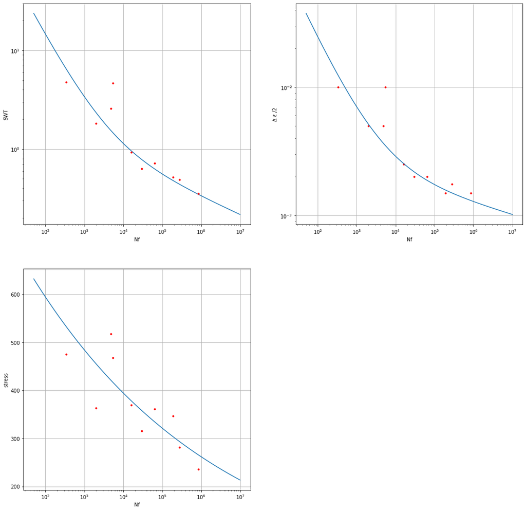

```python
import numpy as np
import matplotlib.pyplot as plt

def generate_data(
        Nf=np.linspace(10,10000000,10000),
        E = 211600,
        sigma_dash = 952.20,
        b = -0.0890,
        epsilon_dash = 0.7371,
        c = -0.6640
    ):
    '''
        generate_data(Nf,E,sigma_dash,b,epsilon_dash,c)->
            SWT,strain,stress,Nf (default for S355)
    '''

    strain =  (sigma_dash/E)*((2*Nf)**b) + epsilon_dash*((2*Nf)**c)
    stress = sigma_dash*((2*Nf)**b)
    SWT = strain*stress
    return SWT,strain,stress,Nf

Nf = 10**np.linspace(1.7,7,50)

SWT,strain,stress,Nf = generate_data(Nf)

# Experimental Data

Exp_strain = np.array([0.005  , 0.0025 , 0.01   , 0.002  , 0.0015 , 0.00175, 0.0015 ,0.002  , 0.005  , 0.01   ])

Exp_stress = np.array([517.39, 369.54, 475.47, 315.4 , 236.34, 281.51, 346.56, 361.21, 363.57, 468.21])

Exp_Nf     = np.array([4805,16175,336,29501,861304,278243,191940,64244,2009,5420])

plt.figure(figsize=(18,18))

plt.subplot(2,2,1)

plt.ylabel('SWT')
plt.xlabel('Nf')
plt.xscale('log')
plt.yscale('log')

plt.plot(Nf,SWT,'-')
plt.plot(Exp_Nf,Exp_strain*Exp_stress,'r.')
plt.grid()

plt.subplot(2,2,2)

plt.ylabel('\u0394 \u03B5 /2')
plt.xlabel('Nf')
plt.xscale('log')
plt.yscale('log')
plt.plot(Exp_Nf,Exp_strain,'r.')
plt.plot(Nf,strain,'-')
plt.grid()
plt.subplot(2,2,3)

plt.ylabel('stress')
plt.xlabel('Nf')
plt.xscale('log')
plt.plot(Nf,stress)
plt.plot(Exp_Nf,Exp_stress,'r.')
plt.grid()
```

# The Model

#### General information on Weibul Distribution

If $X$ is a random variable denoting the *time to failure*, the **Weibull distribution** gives a distribution for which the *failure rate* is proportional to a power of time.

$$ f_X(x) = \frac{\beta}{\delta}(\frac{x-\lambda}{\delta})^{\beta-1}e^{-(\frac{x-\lambda}{\delta})^\beta} $$$$ F_X(x;\lambda,\delta,\sigma) = 1-e^{-({\frac{x-\lambda}{\delta}})^\beta} $$

where $\beta > 0$ is the **shape parameter**,

$\delta > 0$ is the **scale parameter**,

$\lambda > x$ is the **location parameter** (the minimum value of X).

Percentile points,

$$ x_p = \lambda + \delta(-log(1-p))^{\frac{1}{\beta}} $$

where $0\leq p\leq 1$

**Important Properties of Weibull Distribution**

- Stable with respect to location and scale $$ X \sim W(\lambda,\delta,\beta) \iff \frac{X-a}{b} \sim W(\frac{\lambda-a}{b},\frac{\delta}{b},\beta) $$
- It is stable with respect to Minimum Operations.i.e., if $X_1,X_2,X_3,.....X_m$ are independent and identical distribution,then $$ X_i\sim W(\lambda,\delta,\beta) \iff min(X_1,X_2,....,X_m) \sim W(\lambda,\delta m^{\frac{1}{\beta}},\beta) $$ if a set of independent and identical distribution is weibull then its minimum is also a Weibull Random Variable

#### Relevant Variable involved for modeling:

$P$:Probability of fatigue faliure  
$N$:Number of stress cycles to failure  
$N_0$:Threshold value of N (min lifetime)  
$SWT$:Smith,Watson and Topper fatigue damage parameter  
$SWT_0$:Endurance limit

Putting Related variables together we have three varaibles(based on II Theorem)
$$ \frac{N}{N_0},\frac{SWT}{SWT_0},P \\ P = q(\frac{N}{N_0},\frac{SWT}{SWT_0}) $$ where $q()$ is a function we are to determine
so P can be any monotone function of $\frac{N}{N_0},\frac{SWT}{SWT_0}$ , as $h(\frac{N}{N_0})$ $\&$ $g(\frac{SWT}{SWT_0})$

We denote them as $$ N^* = h(\frac{N}{N_0}) \\ SWT^* = g(\frac{SWT}{SWT_0}) $$

#### Justification of Weibull for S-N fields

Considerations:

- **Weakest Link**: Fatigue lifetime of a longitudinal element is the minimum of its constituting particles.Thus we need minimum model for a longitudinal element $L = ml$
- **Stability**: The distribution function must hold for different lengths.
- **Limit Behaviour**: Need Asymptotic family of Distribution
- **Limited Range**: $N^*$ & $SWT^*$ has finite lower bound,coincide with theoretical end of CDF $$ N\geq N_0 \\ SWT \geq SWT_0 $$
- **Compatibility**: $$E(N^*;SWT^*) = F(SWT^*;N^*)$$ i.e., Distribution of $N^*$ can be determined based on given $SWT^*$ and similarly $SWT^*$ from $N^*$.

*All these are Statisfied by Weibull Distribution*

$$E(N^*;SWT^*) = F(SWT^*;N^*)$$

becomes $$ [\frac{SWT^*-\lambda(N^*)}{\delta(N^*)}] ^{\beta(N^*)} = [\frac{N^*-\lambda(SWT^*)}{\delta(SWT^*)}] ^{\beta(SWT^*)} $$

Best fitted Solution: $$ \lambda(N^*) = \frac{\lambda}{N^* - B} \\ \delta(N^*) = \frac{\delta}{N^* - B} \\ \beta(N^*) = \beta $$ and

$$ \lambda(SWT^*) = \frac{\lambda}{SWT^* - C} \\ \delta(SWT^*) = \frac{\delta}{SWT^* - C} \\ \beta(SWT^*) = \beta $$

results in, $$ E[N^*;SWT^*] = F[SWT^*;N^*] \\ \\ = 1 - exp\lbrace -(\frac{(N^*-B)(SWT^*-C)-\lambda}{\delta})^{\beta}\} $$

since $SWT^* \longrightarrow \infty$ a lower end for $N^* = h(\frac{N}{N_0)}) = h(1)$ must exists such that $B = h(1)$,  
similarly for $N^* \longrightarrow \infty$, $C = g(1)$

The percentile curve is constant. $$ \frac{N^*SWT^* - \lambda}{\delta} = constant $$

- The Zero-percentile curve represents the minimum possible $N_f$ for different values of $SWT$ and is a hyperbola As $log$ is used for $N_f$ and $SWT$ we choose, $$ h(x)=g(x) = log(x) $$

therefore, $$ N^* = log(\frac{N}{N_0}) \\ SWT^* = log(\frac{SWT}{SWT_0}) \\ $$

$B = C = log(1) = 0$ $$E(N^*;SWT^*) = F(SWT^*;N^*) \\ = 1 - exp\{-(\frac{N^*SWT^*}{\delta})^{\beta} \} $$

$p$-curves $$ log(\frac{SWT}{SWT^*}) = \frac{\lambda + \delta[-log(1-p)]^{\frac{1}{\beta}}}{log(\frac{N}{N_0})} $$

Final Distribution $$ N^*SWT^* \sim W(\lambda,\delta,\beta) \\ log(\frac{N}{N_0)})log(\frac{SWT}{SWT_0}) \sim W(\lambda,\delta,\beta) \\ log(\frac{N}{N_0)})\sim W(\frac{\lambda}{log(\frac{SWT}{SWT_0}) },\frac{\delta}{log(\frac{SWT}{SWT_0}) },\beta) \\ $$

The values for this model are:

| $logN_0$ | $logSWT_0$ | $\lambda$ | $\delta$ | $\beta$ |
| --- | --- | --- | --- | --- |
| -4.1079 | -4.4317 | 53.8423 | 7.2698 | 3.6226 |

| $logN_0$ | $log\epsilon_{a0}$ | $\lambda$ | $\delta$ | $\beta$ |
| --- | --- | --- | --- | --- |
| -3.2593 | -9.1053 | 36.6676 | 5.8941 | 4.6952 |

[figure not shown]

```python
import math
class Weibull:
    '''
w = Weibull(shape:beta,scale:theta,position:lambda)

    '''
    def __init__(self,shape,scale,loc,x):
        self.shape = shape
        self.scale = scale
        self.loc = loc
        self.x = x
        _,self.bins  = np.histogram(self.x,100,density=True)


    def pdf(self):
        x = self.bins
        shape = self.shape
        scale = self.scale
        loc =  self.loc
        return ((shape/scale)*((x-loc)/scale)**(shape-1))*(np.exp(-((x-loc)/scale)**shape))

    def cdf(self):
        x = self.bins
        shape = self.shape
        scale = self.scale
        loc = self.loc
        return 1- np.exp(-((x-loc)/scale)**shape)

    def failure_rate(self):
        x = self.x
        shape = self.shape
        scale = self.scale
        return (shape/scale)*((x/scale)**(shape-1))

    def E_x(self):
        shape = self.shape
        scale = self.scale
        return np.real(scale*(gamma(1+1/shape)))

    def var_x(self):
        shape = self.shape
        scale = self.scale
        return (scale**2)*(gamma(1+(2/shape))-((gamma(1+(1/shape)))**2))

    def plot_pdf(self):
        plt.plot(self.bins,self.pdf())
        plt.grid()

    def plot_cdf(self):
        plt.plot(self.bins,self.cdf())
        plt.grid()

    def plot_fr(self):
        plt.plot(self.bins,self.failure_rate())
        plt.grid()

    def plot_hist(self):
        plt.hist(self.x)
        plt.grid()

    def get_xp(self,F_x):
        return  np.real(self.loc+(self.scale)*(-(math.log(1-F_x))**(1/self.shape)))

logSWT0 = -4.4317
logN01 = -4.1079

loc1 = 53.8423+9
scale1 = 7.2698
shape1 = 3.6226

X1 = (np.log(Nf) - logN01)*(np.log(SWT) - logSWT0)

#loc1,scale1,shape1 = PWM(np.sort(X1))
w1 = Weibull(shape1,scale1,loc1,X1)

xp101 = w1.get_xp(0.001)
xp105 = w1.get_xp(0.005)
xp150 = w1.get_xp(0.050)
xp195 = w1.get_xp(0.095)
xp199 = w1.get_xp(0.099)

pSWT01 = np.exp(logSWT0 + (xp101/(np.log(Nf)-logN01)))
pSWT05 = np.exp(logSWT0 + (xp105/(np.log(Nf)-logN01)))
pSWT50 = np.exp(logSWT0 + (xp150/(np.log(Nf)-logN01)))
pSWT95 = np.exp(logSWT0 + (xp195/(np.log(Nf)-logN01)))
pSWT99 = np.exp(logSWT0 + (xp199/(np.log(Nf)-logN01)))


plt.figure(figsize=(10,20))
plt.subplot(2,1,1)
plt.title("p-SWT-N")
plt.xlabel("Nf")
plt.ylabel("SWT")
plt.xscale('log')
plt.yscale('log')

# percentile curves
plt.plot(Nf,pSWT01,label="p=1%")
plt.plot(Nf,pSWT05,label="p=5%")
plt.plot(Nf,pSWT50,label="p=50%")
plt.plot(Nf,pSWT95,label="p=95%")
plt.plot(Nf,pSWT99,label="p=99%")
# theoretical data
plt.plot(Nf,SWT,'b.',label="Postulated Data")

# Experimental Data
plt.plot(Exp_Nf,Exp_strain*Exp_stress,'r^',label="Experimental Data")
plt.grid()

plt.legend()


# plt.savefig("images/p_s_n_model.png")
# Strain p-E_a-N

logEa0 = -9.1053
logN02 = -3.2593
loc2 = 36.6676+7
scale2 = 5.8941
shape2 = 4.6952
X2 = (np.log(Nf) - logN02)*(np.log(strain) - logEa0)

w2 = Weibull(shape2,scale2,loc2,X2)

xp201 = w2.get_xp(0.001)
xp205 = w2.get_xp(0.005)
xp250 = w2.get_xp(0.050)
xp295 = w2.get_xp(0.095)
xp299 = w2.get_xp(0.099)

pEa01 = np.exp(logEa0 + (xp201/(np.log(Nf)-logN02)))
pEa05 = np.exp(logEa0 + (xp205/(np.log(Nf)-logN02)))
pEa50 = np.exp(logEa0 + (xp250/(np.log(Nf)-logN02)))
pEa95 = np.exp(logEa0 + (xp295/(np.log(Nf)-logN02)))
pEa99 = np.exp(logEa0 + (xp299/(np.log(Nf)-logN02)))

plt.subplot(2,1,2)
plt.title("p-Ea-N")
plt.xlabel("Nf")
plt.ylabel("Ea")
plt.xscale('log')
plt.yscale('log')

# percentile curves
plt.plot(Nf,pEa01,label="p=1%")
plt.plot(Nf,pEa05,label="p=5%")
plt.plot(Nf,pEa50,label="p=50%")
plt.plot(Nf,pEa95,label="p=95%")
plt.plot(Nf,pEa99,label="p=99%")
# theoretical data
plt.plot(Nf,strain,'b.',label="Postulated Data")
# Experimental Data
plt.plot(Exp_Nf,Exp_strain,'r^')
plt.grid()

plt.legend()
plt.savefig("images/model.png")
```

### p-Nf given SWT

$$ N^*SWT^* \sim W(\lambda,\delta,\beta) \\ log(\frac{N}{N_0)})log(\frac{SWT}{SWT_0}) \sim W(\lambda,\delta,\beta) \\ log(\frac{N}{N_0)})\sim W(\frac{\lambda}{log(\frac{SWT}{SWT_0}) },\frac{\delta}{log(\frac{SWT}{SWT_0}) },\beta) \\ log(\frac{N}{N_0)}) = x_p \\ log(N_f) = x_p + log(N_0) \\ N_f = e^{x_p + log(N_0) } $$

## Determining the fatigue crack propogation curves

$$ \frac{\rho^*}{N_f}=\frac{da}{dN} = C\Delta K^m $$

$\rho^* = 5.5\mu m$

- Determining $p$-$\frac{da}{dN}$-$\Delta K$ curves: $$ log(\frac{N}{N_0)})\sim W(\frac{\lambda}{log(\frac{SWT}{SWT_0}) },\frac{\delta}{log(\frac{SWT}{SWT_0}) },\beta) \\ $$

#### Generating Crack Propogation value:

|  | $C$ | $m$ |
| --- | --- | --- |
| R=0.0 | $7.195x10^{-15}$ | 3.499 |
| R=0.5 | $6.281x10^{-15}$ | 3.555 |
| R=0.7 | $2.037x10^{-13}$ | 3.003 |

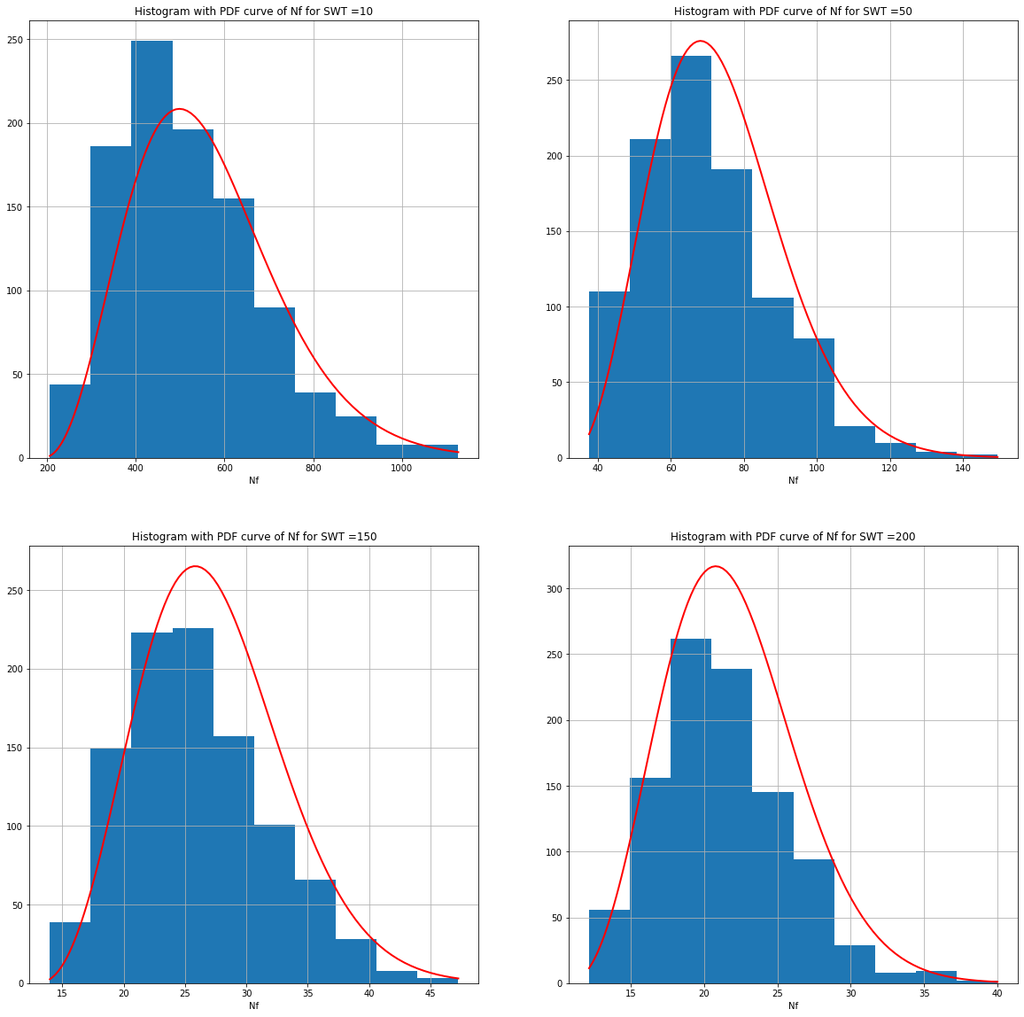

```python
import math

# coping values of p-SWT-N curve

# determing p-Nf for a particular SWT
# say SWT = 9
def plt_pNf(SWT):
    logSWT0 = -4.4317
    lgSWT_SWT0 = math.log(SWT) - logSWT0

    logN01 = -4.1079
    loc3 = (53.8423+9)/lgSWT_SWT0
    scale3 = (7.2698)/lgSWT_SWT0
    shape1 = 3.6226
    #print(loc3,scale3,shape1)
    # X3 Weibull random variable (Nf) given SWT = 9
    X3 = (np.random.weibull(shape1,1000)*scale3) + loc3
    _,bins  = np.histogram(X3,100,density=True)
    pdf = ((shape1/scale3)*((bins-loc3)/scale3)**(shape1-1))*(np.exp(-((bins-loc3)/scale3)**shape1))
    plt.xlabel("Nf")
    plt.title("Histogram with PDF curve of Nf for SWT ="+str(SWT))
    h,_,_ = plt.hist(np.exp(X3+logN01),label='histograph')
    plt.plot(np.exp(bins+logN01),pdf*(h.max()*(0.65)),'r-',label='PDF',linewidth="2")
    plt.grid()

plt.figure(figsize=(20,20))
plt.subplot(2,2,1)
plt_pNf(10)

plt.subplot(2,2,2)
plt_pNf(50)

plt.subplot(2,2,3)
plt_pNf(150)

plt.subplot(2,2,4)
plt_pNf(200)




plt.savefig("images/nfswtpdf.png")
```

##### Probability Weighted Moments(PWM) method to determine Weibull parameters

$$ \frac{3M_2 - M_0}{2M1 - M_0} = \frac{2 - 3.2^{\frac{-1}{\beta}} + 3^{\frac{-1}{\beta}}}{1 - 2^{\frac{-1}{\beta}}} \\ \delta = \frac{2M_1 - M_0}{(1-- 2^{\frac{-1}{\beta}})\Gamma_{\beta}} \\ \lambda = M_0 - \delta \Gamma_{\beta} $$

where $M_r = M_{1,r,0},r = 0,1,2$ and $\Gamma_{\beta} = \Gamma(1 + \frac{1}{\beta})$ and

$$ \hat{M_0} = \frac{1}{n}\sum_{i=1}^n x_i \\ \hat{M_1} = \frac{1}{n(n-1)}\sum_{i=1}^n (i - 1)x_i \\ \hat{M_2} = \frac{1}{n(n-1)(n-2)}\sum_{i=1}^n (i - 1)(i - 2)x_i \\ $$

Since $\beta$ cannot be determined metamatically from the equation Numerical Method is used,

- Newton's Method for Mathematical Approximation $$ x_{n+1} = x_n - \frac{f(x_n)}{f'(x_n)} $$ where, $$ f(x_n) = 2^{x}(C-3) + 3^{x} - (C-2) \\ f'(x_n) = (log2)(2^x)(C-3) + log3(3^x) \\ $$ where $x = \frac{-1}{\beta}$ and $C = \frac{3M_2 - M_0}{2M1 - M_0}$

```python
def getMoments(X):
    n = X.size
    M0 = (1/n)*(X.sum())

    sum1 = 0
    for i in range(n):
        sum1 += i*X[i]
    M1 = (1/((n)*(n-1)))*sum1

    sum2 = 0
    for i in range(n):
        sum2 += i*(i-1)*X[i]
    M2 = (1/(n*(n-1)*(n-2)))*sum2

    return M0,M1,M2

def f(x,C):
    return (2**x)*(C - 3) + (3**x) - (C-2)

def f_dash(x,C):
    return math.log(2)*(2**x)*(C - 3) - math.log(3)*(3**x)

def newton_approx(C,f,f_dash,x=-1,iteration=1000):
    for _  in range(iteration):
        x = x - (f(x,C)/f_dash(x,C))
        #print(x)
    return x

def getpara(M0,M1,M2,newt_init,newt_iterations):
    shape = -1/ newton_approx((3*M2 - M0)/(2*M1 - M0),f,f_dash,x = newt_init,iteration = newt_iterations)
    scale = (2*M1 - M0)/((1 - 2**(-(1/shape)))*math.gamma(1+(1/shape)))
    loc = M0 - scale*(math.gamma(1+(1/shape)))

    return loc,scale,shape

def PWM(X,newt_init=-0.1,newt_iterations = 100):
    return getpara(*getMoments(X),newt_init,newt_iterations)
```

```python
print('predicted values:',PWM(np.sort(X1)))
print('values in  paper:',loc1,scale1,shape1)
```

[output not shown]

```python
A=PWM(np.sort(X1))
B=loc1,scale1,shape1
```

```python
A
```

```
(58.31011426806585, 2.8096569546850514, 2.3081234998763445)
```

```python
B
```

```
(62.8423, 7.2698, 3.6226)
```

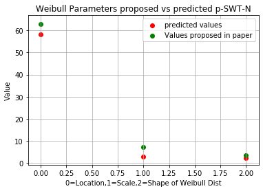

```python
plt.title("Weibull Parameters proposed vs predicted p-SWT-N")
plt.scatter(np.arange(0,3),A,c="r",label="predicted values")
plt.scatter(np.arange(0,3),B,c="g",label="Values proposed in paper")

plt.ylabel('Value')
plt.xlabel('0=Location,1=Scale,2=Shape of Weibull Dist')
plt.legend()
plt.grid()
plt.savefig("images/PWMPlotswt.png")
```

```python
print("Predicted (Location, Scale,Shape) = " , A)
print("Proposed in Paper(Location, Scale, Shape) = ", B)
```

[output not shown]

[figure not shown]

```python
# added
X1_pred = (np.log(Nf) + 3.84135)*(np.log(SWT) + 4.3838)
# --
# added
w1_pred = Weibull(2.3081,2.8096,58.31011,X1_pred)
xp150_pred = w1_pred.get_xp(0.050)

pSWT50_pred = np.exp((-4.3838) + (xp150_pred/(np.log(Nf)-(-3.84135))))

# --

# percentile curve of predicted values

plt.title("p-SWT-N (Predicted parameters)")
plt.xlabel("Nf")
plt.ylabel("SWT")
plt.xscale('log')
plt.yscale('log')
plt.plot(Nf,pSWT50_pred,'-',label="p=50%")
# theoretical data
plt.plot(Nf,SWT,'b.',label="Postulated Data")

# Experimental Data
plt.plot(Exp_Nf,Exp_strain*Exp_stress,'r^',label="Experimental Data")
plt.grid()

plt.legend()

plt.savefig("images/p-SWT-Nf_predpara.png")
```

[output not shown]

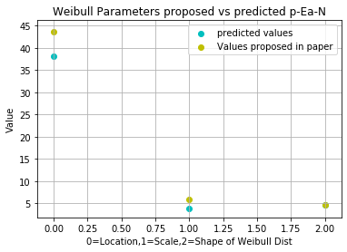

```python
A=PWM(np.sort(X2))
B=loc2,scale2,shape2
plt.title("Weibull Parameters proposed vs predicted p-Ea-N")
plt.scatter(np.arange(0,3),A,c="c",label="predicted values")
plt.scatter(np.arange(0,3),B,c="y",label="Values proposed in paper")

plt.ylabel('Value')
plt.xlabel('0=Location,1=Scale,2=Shape of Weibull Dist')
plt.legend()
plt.grid()
plt.savefig("images/PWMPlotstrain.png")
print("Predicted (Location, Scale,Shape) = " , A)
print("Proposed in Paper(Location, Scale, Shape) = ", B)
```

[figure not shown]

```python
# added
X2_pred = (np.log(Nf) + 3.21691)*(np.log(strain) + 9.1053)
w2_pred = Weibull(4.67477,3.869499,38.115144,X2_pred)

xp250_pred = w2_pred.get_xp(0.050)

pEa50_pred = np.exp((-9.1053) + (xp250/(np.log(Nf) + 3.21691)))


plt.title("p-Ea-N (Predicted Parameters)")
plt.xlabel("Nf")
plt.ylabel("Ea")
plt.xscale('log')
plt.yscale('log')

plt.plot(Nf,pEa50_pred,label="p=50%")


plt.plot(Nf,strain,'b.',label="Postulated Data")
# Experimental Data
plt.plot(Exp_Nf,Exp_strain,'r^')
plt.grid()

plt.legend()
#--

plt.savefig("images/p-Ea-Nf_predpara.png")
```

##### Estimation of Threshold Value $(N_0,\Delta\sigma_0)$

Using the analysis done by Castillo, E. and Galambos, J. [20] for lifetime regression models we formulate the following to predict the $SWT_0 and N_0$

$$ E[log(\frac{N}{N_0)}) | log(\frac{\Delta SWT}{\Delta SWT_0)})] = \frac{E[N^*\Delta SWT^*]}{log(\frac{\Delta SWT}{\Delta SWT_0)})} \\ E[log(N) | log(\frac{\Delta SWT}{\Delta SWT_0)})] = log(N_0) + \frac{K}{log(\frac{\Delta SWT}{\Delta SWT_0)})} \\ where, K = \lambda + \delta\Gamma(1+\frac{1}{\beta}) $$

Minimize Error Function $Q$ $$ Q = \sum_{i=0}^m\sum_{j=1}^{n_i}(logN_{ij} - logN_0 - \frac{K}{log\Delta SWT_i - log\Delta SWT_0})^2 $$ to get $logN_0$ and $log\Delta SWT_0$

We further minimise this cost function using a Gradient Descent algorithm to find optimal values of $N_0$ and $SWT_0$

**The intial Estimation of Threshold**

- The starting parameters provided to gradient descent are calculated mathematically using, $$ \mu_i = \frac{1}{n_i}\sum_{j=1}^{n_i}(logN_{ij} = logN_0 - \frac{K}{log\Delta SWT_i - log\Delta SWT_0})^2 $$

##### Gradient Descent

Gradient Descent is used to find the minimun of a function known as cost function, here in our case is the error function.Gradient Descent is a iterative learning algorithm and with each step it moves closer to the minimum based on the gradient of the cost function and learning rate. $$ Cost function = J(\theta) \\ Gradient = \frac{\partial J(\theta)}{\partial \theta_i} \\ New parameter = \theta_i = \theta_i - \alpha \frac{\partial J(\theta)}{\partial \theta_i} \\ $$ where $\theta$ are the parameters and $\alpha$ is the learning rate.Here, $$ Cost function = Q = \sum_{i=0}^m\sum_{j=1}^{n_i}(logN_{ij} - logN_0 - \frac{K}{log\Delta SWT_i - log\Delta SWT_0})^2 \\ \frac{\partial Q}{\partial logN_0} = \frac{1}{M}\sum -2(logN - logN_0 - \frac{K}{log\Delta SWT_i - log\Delta SWT_0}) \\ \frac{\partial Q}{\partial K} = \frac{1}{M}\sum \frac{-2}{log\Delta SWT_i - log\Delta SWT_0}(logN - logN_0 - \frac{K}{log\Delta SWT_i - log\Delta SWT_0}) \\ \frac{\partial Q}{\partial logSWT_0} = \frac{1}{M}\sum \frac{-2b}{(log\Delta SWT_i - log\Delta SWT_0)^2}(logN - logN_0 - \frac{K}{log\Delta SWT_i - log\Delta SWT_0}) $$

```
initial estimation of parameters : -3.207753151127962 57.51059490872167 -4.458919712990903
```

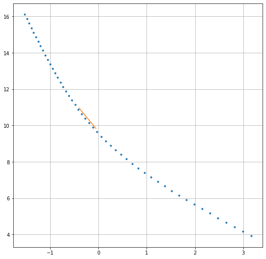

```python
Nf_logged=np.log(Nf)
swt_logged=np.log(SWT)

plt.figure(figsize=(20,20))
plt.subplot(2,2,1)
# ploting the distribution
plt.plot(swt_logged,Nf_logged,'.')

# determine the initial estimation
def initial_est(Nf_logged,stress_logged):

    x1 = np.mean(stress_logged[0:16])
    x2 = np.mean(stress_logged[16:32])
    x3 = np.mean(stress_logged[32:48])
    y1 = np.mean(Nf_logged[0:16])
    y2 = np.mean(Nf_logged[16:32])
    y3 = np.mean(Nf_logged[32:48])

    c = (x2*(x3-x1)*(y1-y2) - x3*(x2-x1)*(y1-y3)) / ((x3-x1)*(y1-y2)-(x2-x1)*(y1-y3))
    b = ((y1-y2)*(x2-c)*(x1-c))/(x2-x1)
    a = y1 - (b/(x1-c))
    return a,b,c

int_a,int_b,int_c = initial_est(Nf_logged,swt_logged)

# plot intial estimation
int_points = np.array([-0.4,-0.05]) # start and end points based on graph of experimental values
int_val = int_a + (int_b/(int_points - int_c)) # values corresponind to that points based on initial parameters

plt.plot(int_points,int_val,label="initial estimation")
plt.grid()

print('initial estimation of parameters :',int_a,int_b,int_c)

# Better the estimation with gradient Descent

# Cost loss function
def cal_cost(a,b,c,X,Y):
    cost = (Y - a - (b/(X - c)))**2
    return np.mean(cost)/2

def predict(a,b,c,X,Y,alpha):

    G_a = (-2)*(Y - a - (b/(X-c)))
    G_b = (-2)*(Y - a - (b/(X-c)))*(1/X-c)
    G_c = (-2)*(Y - a - (b/(X-c)))*(b/((X-c)**2))

    a_new = a - (alpha*(np.mean(G_a)))
    b_new = b - (alpha*(np.mean(G_b)))
    c_new = c - (alpha*(np.mean(G_c)))
    #print(np.mean(G_a),np.mean(G_b),np.mean(G_c))
    return a_new,b_new,c_new

def gradient_desc(a,b,c,X,Y,alpha= 0.001,iterations=3000):
    cost_history = np.zeros(iterations)
    para_history = np.zeros((iterations,3))
    for i in range(iterations):
        para_history[i,:] = np.array([a,b,c])
        a,b,c = predict(a,b,c,X,Y,alpha)
        cost_history[i] = cal_cost(a,b,c,X,Y)
        #print(m,c)
    return [a,b,c],para_history,cost_history

pred=gradient_desc(int_a,int_b,int_c,Nf_logged,swt_logged)
```

```python
pred[0]
```

```
[-3.8413545070878463, 54.65306079459594, -4.383809373097227]
```

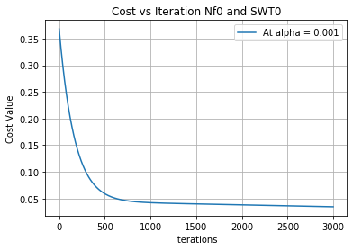

```python
plt.title("Cost vs Iteration Nf0 and SWT0")
plt.xlabel("Iterations")
plt.ylabel("Cost Value")
plt.grid()
plt.plot(pred[2],label="At alpha = 0.001")
plt.legend()
plt.savefig("images/costviterswt.png")
```

The values for this model are:

| $logN_0$ | $logSWT_0$ | $\lambda$ | $\delta$ | $\beta$ |
| --- | --- | --- | --- | --- |
| -4.1079 | -4.4317 | 53.8423 | 7.2698 | 3.6226 |

```
initial estimation of parameters : -0.14627170999350003 23.74638073430922 -9.042803939998716
```

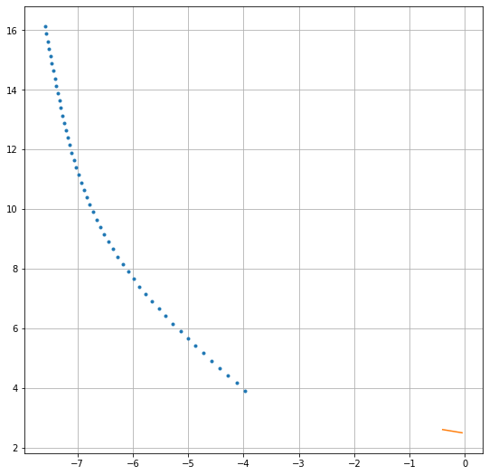

```python
Nf_logged=np.log(Nf)
strain_logged=np.log(strain/2)

plt.figure(figsize=(20,20))
plt.subplot(2,2,1)
# ploting the distribution
plt.plot(strain_logged,Nf_logged,'.')

# determine the initial estimation
def initial_est(Nf_logged,stress_logged):

    x1 = np.mean(stress_logged[0:16])
    x2 = np.mean(stress_logged[16:32])
    x3 = np.mean(stress_logged[32:48])
    y1 = np.mean(Nf_logged[0:16])
    y2 = np.mean(Nf_logged[16:32])
    y3 = np.mean(Nf_logged[32:48])

    c = (x2*(x3-x1)*(y1-y2) - x3*(x2-x1)*(y1-y3)) / ((x3-x1)*(y1-y2)-(x2-x1)*(y1-y3))
    b = ((y1-y2)*(x2-c)*(x1-c))/(x2-x1)
    a = y1 - (b/(x1-c))
    return a,b,c

int_a,int_b,int_c = initial_est(Nf_logged,strain_logged)

# plot intial estimation
int_points = np.array([-0.4,-0.05]) # start and end points based on graph of experimental values
int_val = int_a + (int_b/(int_points - int_c)) # values corresponind to that points based on initial parameters

plt.plot(int_points,int_val,label="initial estimation")
plt.grid()

print('initial estimation of parameters :',int_a,int_b,int_c)

# Better the estimation with gradient Descent

# Cost loss function
def cal_cost(a,b,c,X,Y):
    cost = (Y - a - (b/(X - c)))**2
    return np.mean(cost)/2

def predict(a,b,c,X,Y,alpha):

    G_a = (-2)*(Y - a - (b/(X-c)))
    G_b = (-2)*(Y - a - (b/(X-c)))*(1/X-c)
    G_c = (-2)*(Y - a - (b/(X-c)))*(b/((X-c)**2))

    a_new = a - (alpha*(np.mean(G_a)))
    b_new = b - (alpha*(np.mean(G_b)))
    c_new = c - (alpha*(np.mean(G_c)))
    #print(np.mean(G_a),np.mean(G_b),np.mean(G_c))
    return a_new,b_new,c_new

def gradient_desc(a,b,c,X,Y,alpha= 0.0003,iterations=1050):
    cost_history = np.zeros(iterations)
    para_history = np.zeros((iterations,3))
    for i in range(iterations):
        para_history[i,:] = np.array([a,b,c])
        a,b,c = predict(a,b,c,X,Y,alpha)
        cost_history[i] = cal_cost(a,b,c,X,Y)
        #print(m,c)
    return [a,b,c],para_history,cost_history

pred=gradient_desc(int_a,int_b,int_c,Nf_logged,strain_logged)
```

```python
pred[0]
```

```
[-3.2169137446018166, -4.544872577340627, -9.12850244974238]
```

| $logN_0$ | $log\epsilon_{a0}$ | $\lambda$ | $\delta$ | $\beta$ |
| --- | --- | --- | --- | --- |
| -3.2593 | -9.1053 | 36.6676 | 5.8941 | 4.6952 |

[figure not shown]

```python
plt.title("Cost vs Iteration Nf0 and Ea0 ")
plt.xlabel("Iterations")
plt.ylabel("Cost Value")
plt.grid()
plt.plot(pred[2],label="At alpha = 0.001")
plt.legend()
plt.savefig("images/costviterEa.png")
```

[figure not shown]

```python
constlogN0=-3.2593
constlogEa0=-9.1053
predlogN0=-3.2169137446018166
predlogEa0=-9.12850244974238

A=constlogN0,constlogEa0
B=predlogN0,predlogEa0
plt.title("Strain-Life Field Parameters proposed  vs predicted ")
plt.scatter(np.arange(0,2),A,c="c",label="predicted values")
plt.scatter(np.arange(0,2),B,c="y",label="Values proposed in paper")

plt.ylabel('Value')
plt.xlabel('0=LogN0,1=LogEa0')
plt.legend()
plt.grid()
plt.savefig("images/StrainLifePropvPred.png")
```

[figure not shown]

```python
constlogN0swt=-4.1079
constlogSWT=-4.4317
predlogN0swt=-3.8413545070878463
predlogSWT=-4.383809373097227

A=constlogN0swt,constlogSWT
B=predlogN0swt,predlogSWT
plt.title("SWT-Life Field Parameters proposed in paper vs predicted ")
plt.scatter(np.arange(0,2),A,c="r",label="predicted values")
plt.scatter(np.arange(0,2),B,c="b",label="Values proposed in paper")

plt.ylabel('Value')
plt.xlabel('0=LogN0,1=LogSWT0')
plt.legend()
plt.grid()
plt.savefig("images/SWTLifePropvPred.png")
```